# Homework 4

Boray Yurdakul - ETM58d - Spring 2020

1. [Codes for Homework 4](https://github.com/ETM-58D/spring20-borayyurdakul/blob/master/files/hw4.R)

   In part a, we prepared a homepage which is illustrated below. We put some rules for the date filter which are minimum and maximum dates as 2017-01-01, 2019-12-29. In sidebar, user can filter data and see the date, hour, consumption and average temperature values over the filtered range.

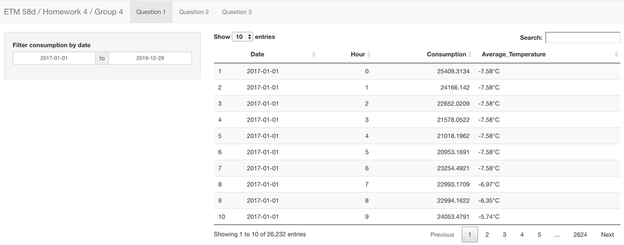

   In part b, the sidebar is same as the part a, user can filter date and see average consumption and temperature values based on 24-hour. Date range is limited with the minimum (2017-01-01) and maximum (2019-12-29) values. As user chooses different date ranges, 2 plots are changed simultaneously. The plot on the upper part shows average hourly consumption over the filtered time period. Average consumption values are on the y-axis, while hour values are on the x-axis. The other plot which is below shows that the average hourly temperature for multiple cities (T_1, T_2, T_3…). Also, in the plot, average temperature values are on y-axis and hour values are on the x-axis.

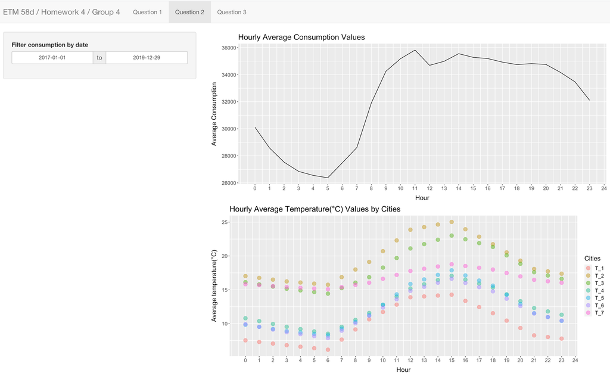

   In part c, left side of the page is as same as the other parts but date range are limited with the minimum (2017-01-01) and maximum (2019-12-27) values. In this part, we used the data which are 2-days and 7-days before to predict the consumption values. In the question, we are asked to show forecasted hourly consumption values but there is a rule. The rule says that if user chooses the following date range, 2019-05-07 and 2019-07-09, the graph shows the hourly consumption for 2019-07-11. The Forecasted Consumption Value graph is only affected by the end date of the date range.

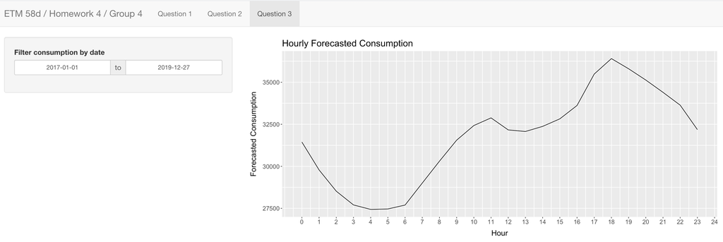

   Please click [here](https://github.com/ETM-58D/spring20-borayyurdakul/blob/master/files/hw4.docx) for plots and more details.